# Tuango Analysis

Section 81

Dain Hall

# Preliminaries

### Determine notebook defaults:

### Load packages:

### Read in the data:

```r
# use load("filename.Rdata") for .Rdata files
# rm(list=ls())
load("/Users/dain/Programs/R_Projects/MKTG_482_HW2/Tuango_rfm.Rdata")
```

# Assignment answers

## Question 1

What percentage of customers responded (i.e. bought anything) after the push message?

```r
tuango %>% filter(buyer==1) %>%
  summarise(perc_buyer=percent(n()/nrow(tuango), 0.01))
```

| perc_buyer |
| --- |
| 3.10% |

## Question 2

Of those who bought, what was the average spending?

(Hint: use filter(buyer==1) in the dplyr package to grab the relevant rows in the data.)

```r
tuango %>% filter(buyer==1) %>%
  summarise(average_spend=dollar(mean(ordersize)))
```

| average_spend |
| --- |
| $202.36 |

## Question 3

Create (independent) quintile variables for recency, frequency and monetary. Display a table with the first six observations of the quintile variables only.

(Hint: review the file “RFM_BBB.Rmd” which goes through the calculations for the Bookbinders RFM analysis).

```r
tuango_iq <- tuango %>%
  mutate(rec_quin_i = ntile(recency, 5),
         freq_quin_i = ntile(-frequency, 5),
         mon_quin_i = ntile(-monetary, 5))

tuango_iq %>%
  select(recency, frequency, monetary, rec_quin_i, freq_quin_i, mon_quin_i) %>%
  slice(0:6)
```

| recency | frequency | monetary | rec_quin_i | freq_quin_i | mon_quin_i |
| --- | --- | --- | --- | --- | --- |
| 309 | 7 | 39.8 | 5 | 1 | 3 |
| 297 | 8 | 39.8 | 5 | 1 | 3 |
| 295 | 1 | 72.9 | 5 | 3 | 2 |
| 277 | 1 | 40.0 | 5 | 3 | 3 |
| 259 | 1 | 21.0 | 5 | 3 | 4 |
| 243 | 1 | 19.9 | 5 | 3 | 4 |

## Question 4

Create bar chart showing the response rate (i.e., the proportion of customers who bought something) to this deal by • recency quintile • frequency quintile • monetary quintile

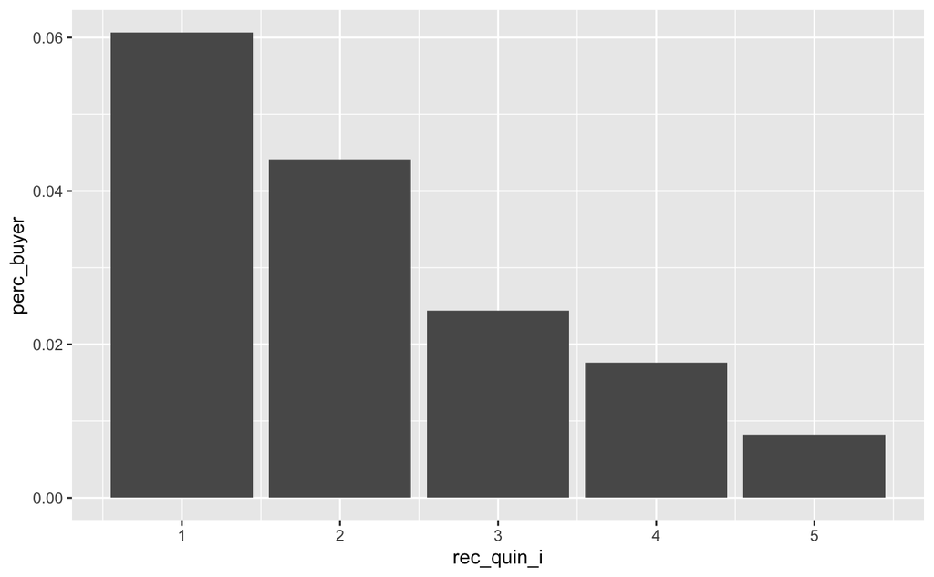

```r
tuango_iq %>%
  group_by(rec_quin_i) %>%
  summarize(perc_buyer = mean(buyer)) %>%
  ggplot() + geom_col(aes(x = rec_quin_i, y = perc_buyer))
```

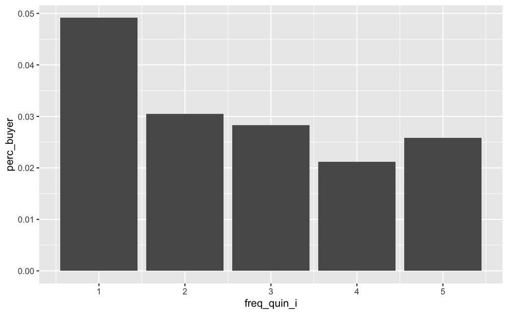

```r
tuango_iq %>%
  group_by(freq_quin_i) %>%
  summarize(perc_buyer = mean(buyer)) %>%
  ggplot() + geom_col(aes(x = freq_quin_i, y = perc_buyer))
```

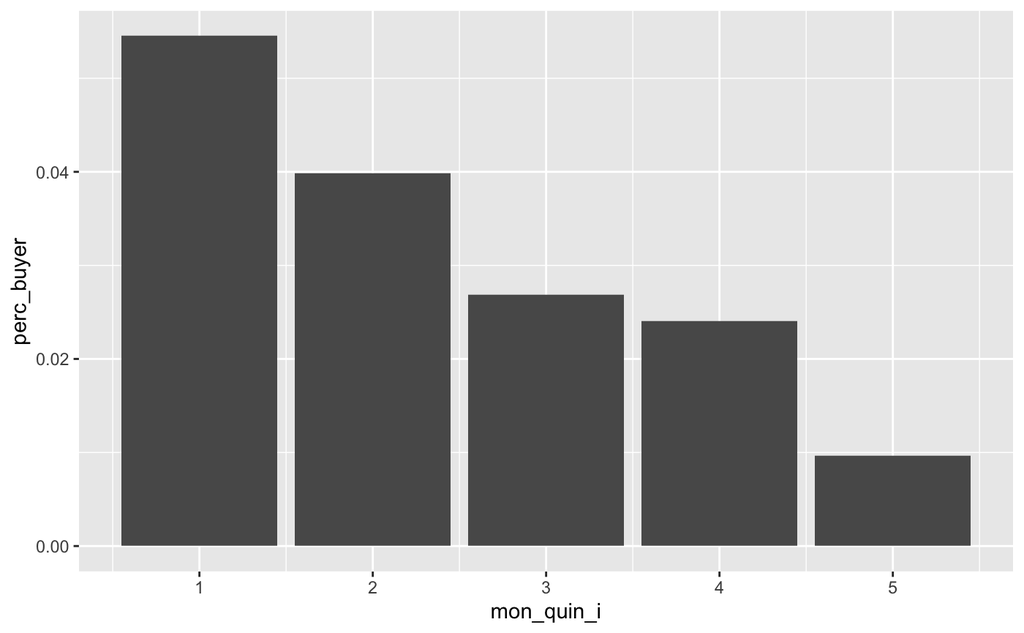

```r
tuango_iq %>%
  group_by(mon_quin_i) %>%
  summarize(perc_buyer = mean(buyer)) %>%
  ggplot() + geom_col(aes(x = mon_quin_i, y = perc_buyer))
```

## Question 5

Repeat questions 4 using only those customers who placed an order after the push message, i.e. create bar charts showing the average spending (in RMB) by recency, frequency and monetary quintile.

(Hint: use filter(buyer==1) in the dplyr package to first create a dataframe containing only consumers who placed an order. Use that dataframe as an input to ggplot.)

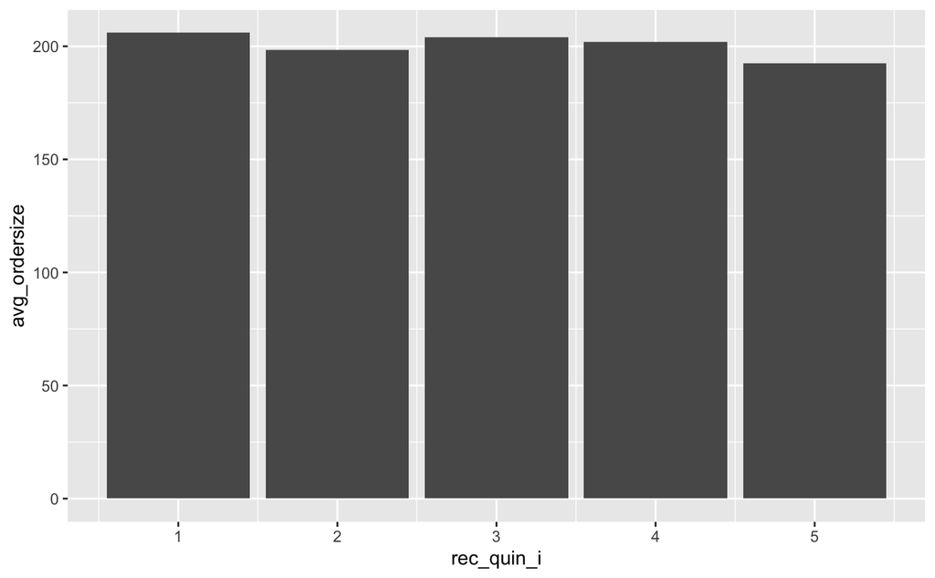

```r
tuango_iq %>%
  filter(buyer==1) %>%
  group_by(rec_quin_i) %>%
  summarize(avg_ordersize = mean(ordersize)) %>%
  ggplot() + geom_col(aes(x = rec_quin_i, y = avg_ordersize))
```

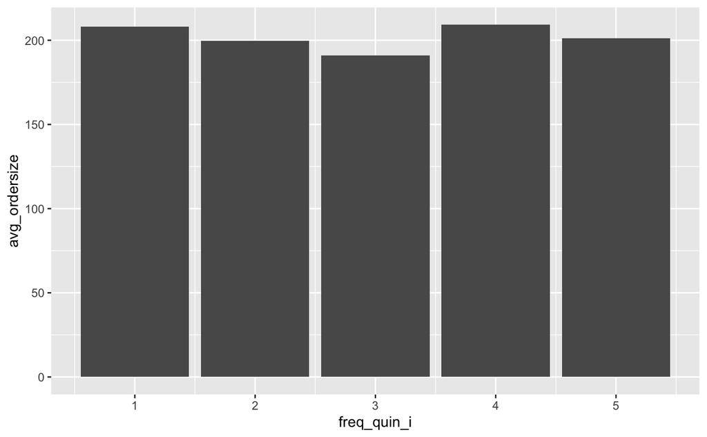

```r
tuango_iq %>%
  filter(buyer==1) %>%
  group_by(freq_quin_i) %>%
  summarize(avg_ordersize = mean(ordersize)) %>%
  ggplot() + geom_col(aes(x = freq_quin_i, y = avg_ordersize))
```

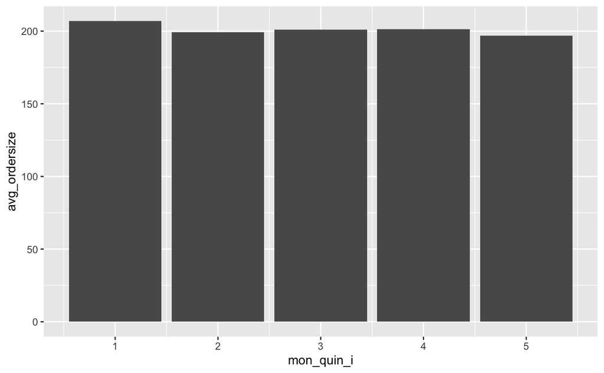

```r
tuango_iq %>%
  filter(buyer==1) %>%
  group_by(mon_quin_i) %>%
  summarize(avg_ordersize = mean(ordersize)) %>%
  ggplot() + geom_col(aes(x = mon_quin_i, y = avg_ordersize))
```

## Question 6

What do the above bar charts reveal about the likelihood of response and the size of the order across the different recency, frequency, and monetary quintiles?

```r
"
The response rates of the first and second quintile of Recency & Monetary are fairly higher than the last 3 quintiles. The first Frequency quintile is higher, but the other 4 quintiles are relatively the same. It appears there is very little difference amongst the avg ordersize quintiles, so purchasing behavior is relatively uniform.
"
```

```
[1] "\nThe response rates of the first and second quintile of Recency & Monetary are fairly higher than the last 3 quintiles. The first Frequency quintile is higher, but the other 4 quintiles are relatively the same. It appears there is very little difference amongst the avg ordersize quintiles, so …
```

# Part 2

## Question 7

Create the independent RFM index in R.

```r
tuango_iq <- tuango_iq %>%
  mutate(rfmindex_iq = paste(rec_quin_i, freq_quin_i, mon_quin_i, sep = ''))

tuango_iq %>%
  select(rec_quin_i, freq_quin_i, mon_quin_i, rfmindex_iq) %>%
  head()
```

| rec_quin_i | freq_quin_i | mon_quin_i | rfmindex_iq |
| --- | --- | --- | --- |
| 5 | 1 | 3 | 513 |
| 5 | 1 | 3 | 513 |
| 5 | 3 | 2 | 532 |
| 5 | 3 | 3 | 533 |
| 5 | 3 | 4 | 534 |
| 5 | 3 | 4 | 534 |

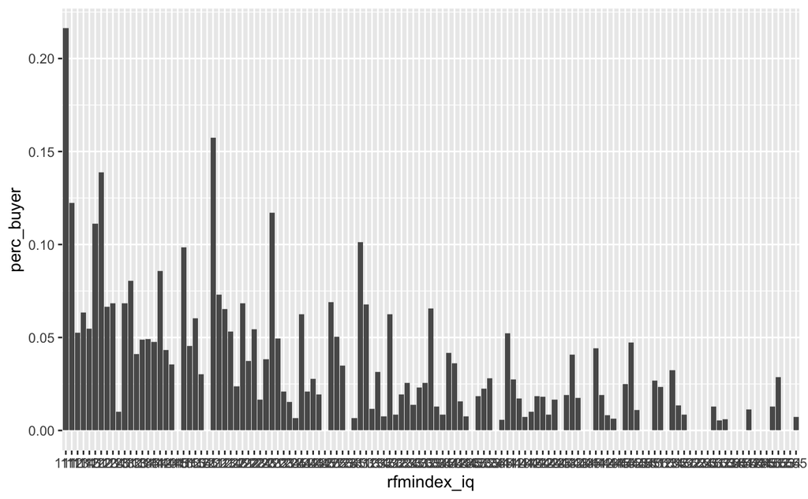

```r
tuango_iq %>%
  group_by(rfmindex_iq) %>%
  summarise(perc_buyer=mean(buyer)) %>%
  ggplot() + geom_col(aes(x = rfmindex_iq, y = perc_buyer))
```

## Question 8

Create the sequential RFM index in R.

```r
tuango_iq_sq <- tuango_iq %>%
  mutate(rec_quin_s = ntile(recency, 5)) %>%
  group_by(rec_quin_s) %>%
  mutate(freq_quin_s = ntile(-frequency, 5)) %>%
  group_by(rec_quin_s, freq_quin_s) %>%
  mutate(mon_quin_s = ntile(-monetary, 5)) %>%
  ungroup()

tuango_iq_sq <- tuango_iq_sq %>%
  mutate(rfmindex_sq = paste(rec_quin_s, freq_quin_s, mon_quin_s, sep = ''))

tuango_iq_sq %>%
  select(rec_quin_s, freq_quin_s, mon_quin_s,rfmindex_sq) %>%
  head()
```

| rec_quin_s | freq_quin_s | mon_quin_s | rfmindex_sq |
| --- | --- | --- | --- |
| 5 | 1 | 4 | 514 |
| 5 | 1 | 4 | 514 |
| 5 | 3 | 2 | 532 |
| 5 | 3 | 3 | 533 |
| 5 | 3 | 4 | 534 |
| 5 | 3 | 5 | 535 |

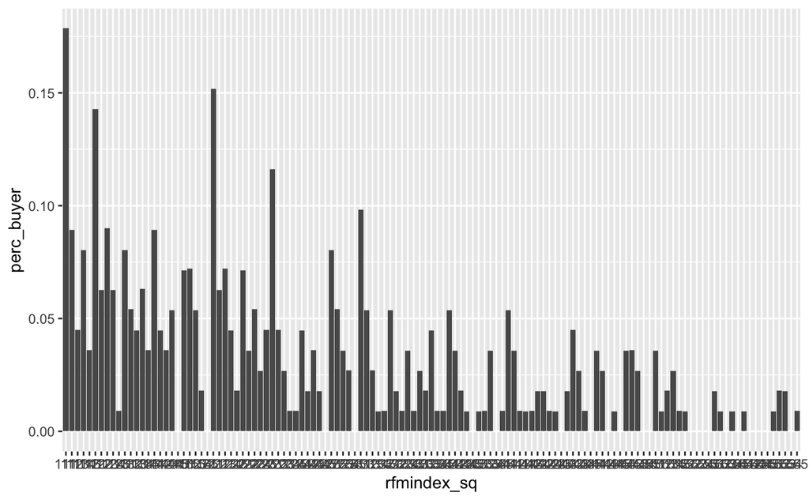

```r
tuango_iq_sq %>%
  group_by(rfmindex_sq) %>%
  summarise(perc_buyer=mean(buyer)) %>%
  ggplot() + geom_col(aes(x = rfmindex_sq, y = perc_buyer))
```

## Question 9

Visually examine the observations in the database. What do you notice about the independent and sequential index values? That is – do the two approaches generally yield the same RFM index for any given customer? What do you see as the pros and cons of the two approaches (from a statistical as well as logical perspective) and why?

(Hint: Calculate and compare how many consumers are in each “cell” for the independent and sequential index. You can count the number of observations using the dplyr summarise(n()) function.)

```r
tuango_iq %>%
   group_by(rfmindex_iq) %>% summarise(count=n()) %>% arrange(desc(count)) %>%
   arrange(desc(rfmindex_iq)) %>%
   slice(0:10)
```

| rfmindex_iq | count |
| --- | --- |
| 555 | 138 |
| 554 | 52 |
| 553 | 71 |
| 552 | 105 |
| 551 | 155 |
| 545 | 78 |
| 544 | 109 |
| 543 | 112 |
| 542 | 88 |
| 541 | 86 |

```r
tuango_iq_sq %>%
   group_by(rfmindex_sq) %>% summarise(count=n()) %>% arrange(desc(count)) %>%
   arrange(desc(rfmindex_sq)) %>%
   slice(0:10)
```

| rfmindex_sq | count |
| --- | --- |
| 555 | 111 |
| 554 | 111 |
| 553 | 112 |
| 552 | 111 |
| 551 | 112 |
| 545 | 111 |
| 544 | 111 |
| 543 | 112 |
| 542 | 111 |
| 541 | 112 |

```r
"
The results are predominantly the same (the graphs are similar). Sequential method results in more evenly distributed customer count within each cell.˘

Sequential (Nested):
Pros:
* Even distribution of customers within each RFM cell / group
Cons:
* Assignment of customers and the results become harder to intrepet.

Independent:
Pros:
* Unambiguous assigment for 3 RFM categories.
Cons:
* For smaller samples, may result in less even distribution of combined RFM scores (more empty cells)
"
```

```
[1] "\nThe results are predominantly the same (the graphs are similar). Sequential method results in more evenly distributed customer count within each cell.˘\n\nSequential (Nested):\nPros:\n* Even distribution of customers within each RFM cell / group\nCons:\n* Assignment of customers and the resul…
```

# Part 3

## Question 10

What is the breakeven response rate?

```r
# Marginal Cost: 2.5RMB
# Fee per sale: 50%
# Average Order Size: ~$202

marginal_cost <- 2.5
gross_rev <- tuango %>% filter(buyer==1) %>%
  summarise(average_spend=mean(ordersize))
rev_split <- 0.5
net_rev <- gross_rev$average_spend * rev_split
response_rate <- marginal_cost / net_rev
percent(response_rate, 0.01)
```

```
[1] "2.47%"
```

## Question 11

What is the projected profit in RMB if you offer the deal to all remaining 264,841 customers.

[output not shown]

## Question 12

Consider offering the deal only to those of the 264,841 customers in RFM cells (using the sequential n-tiles approach) with a response rate that is equal to or greater than the breakeven response rate. * Calculate the response rate for the sequential quintiles approach. * Merge the response rate back into main data. * Calculate who you should have mailed to in your data. * Calculate the projected profit in RMB. What is it?

(Hint: review the file “RFM_BBB.Rmd” which goes through the calculations in the Bookbinders RFM analysis).

```r
resp_rate_sq_df <- tuango_iq_sq %>%
  group_by(rfmindex_sq) %>%
  summarise(resp_rate_sq=mean(buyer)) %>%
  ungroup()

tuango_final <- tuango_iq_sq %>%
  left_join(resp_rate_sq_df)
tuango_final <- tuango_final %>%
  mutate(mailto_sq=1*(resp_rate_sq>response_rate))

targeted_customers_sq <- tuango_final %>%
  filter(mailto_sq==1) %>%
  summarise(frac_mailed=n()/nrow(tuango_final), resp_rate=mean(buyer))

# targeted_customers_sq

ntargeted_customers <- 264841 * targeted_customers_sq$frac_mailed
targeted_resp_rate <- targeted_customers_sq$resp_rate

dollar(ntargeted_customers * targeted_resp_rate * net_rev - (ntargeted_customers * marginal_cost))
```

```
[1] "$404,472"
```